# Homework to StatComp22074

22074

2022-12-05

## Overview

**StatComp22074** is a simple R package, which shows all the answers to the past homework of 22074, including all the contents of HW0-HW10.

## HW0

### Question

Use knitr to produce at least 3 examples (texts, figures, tables).

### Answer

#### Example 1

We can import the CARS dataset containing 50 pieces of data, which give the speed of cars and the distances taken to stop. Store the data in the variable Speed and Dist, and display some of the data as follows.

```r
Speed <- cars$speed
Dist <- cars$dist
print(xtable::xtable(head(cars)),type = "html")
```

|  | speed | dist |
| --- | --- | --- |
| 1 | 4.00 | 2.00 |
| 2 | 4.00 | 10.00 |
| 3 | 7.00 | 4.00 |
| 4 | 7.00 | 22.00 |
| 5 | 8.00 | 16.00 |
| 6 | 9.00 | 10.00 |

At the same time, we can output basic information of the CARS dataset.

```r
summary(cars)
```

```
##      speed           dist
##  Min.   : 4.0   Min.   :  2.00
##  1st Qu.:12.0   1st Qu.: 26.00
##  Median :15.0   Median : 36.00
##  Mean   :15.4   Mean   : 42.98
##  3rd Qu.:19.0   3rd Qu.: 56.00
##  Max.   :25.0   Max.   :120.00
```

#### Example 2

We can performe linear regression analysis on the CARS dataset.

```r
lm.cars <- lm(Dist~Speed)
summary(lm.cars)$coef
```

```
##               Estimate Std. Error   t value     Pr(>|t|)
## (Intercept) -17.579095  6.7584402 -2.601058 1.231882e-02
## Speed         3.932409  0.4155128  9.463990 1.489836e-12
```

We can output the text version of the results as above and obtain the estimation of regression equation as,

$$Dist=-17.579095+3.932409\times
Speed$$

also we can discover that $p-value$ of Speed is $1.489836e-12$. Therefore, we can assume that the distances taken to stop is affected by the speed of cars at the significance level of $\alpha =0.05$.

#### Example 3

We can also plot the regression results as follows, and it can be found that the linear model fits well.

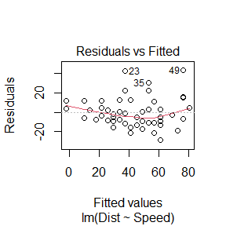

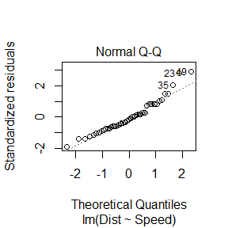

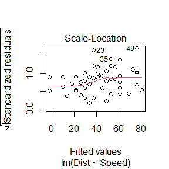

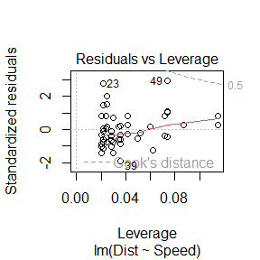

```r
#par(mfrow=c(2,2))
plot(lm.cars)
```

## HW1

HW1 is used to generate random numbers.

### Question 3.3

For the Pareto(a,b) distribution
$$F(x)=1-(\frac{b}{x})^a,x\geq
b>0,a>0.$$
We need to derive $F^{-1}(U)$ and use it to simulate sample from Pareto(2,2). Besides, we need to graph the density histogram of samples and Pareto(2,2).

Exercise1 of HW1 mainly generated random numbers with Pareto(2,2) distributions and drew corresponding histograms.

### Answer 3.3

Since $X$ is a continuous random variable with cdf $F_X(x)$, $U=F_X(X)\sim U(0,1)$, and $F^{-1}_X(U)$ has the same distribution as $X$. We can make
$$F(x)=1-(\frac{b}{x})^a=u,u\in [0,1), x\geq
b>0,a>0$$
$$1-u=(\frac{b}{x})^a$$
$$(1-u)^{1/a}=\frac{b}{x}$$
$$F^{-1}(u)=x=\frac{b}{(1-u)^{1/a}},u\in
[0,1),a>0$$

Thereforce, we have
$$F^{-1}(U)=\frac{b}{(1-U)^{1/a}},a>0,U\sim
U(0,1).$$

Then we can use the inverse transform method to simulate a random sample from the Pareto(2, 2) by making $a=b=2$, and use $n=1000$.

Since we know when $U\sim U(0,1)$, $U'=1-U\sim U(0,1)$, we can make $F^{-1}(U')=\frac{b}{(U')^{1/a}},a>0,U'\sim U(0,1)$. Besides, we can easily know
$$f(x)=\frac{8}{x^3},x\geq 2.$$

1. Generate $U'\sim U(0,1)$.
2. Return $X=F^{-1}(U')$.

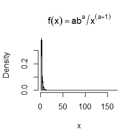

```r
rdistPareto = function(n = 1e3,a = 2,b = 2,picture = FALSE){
  u <- runif(n) # Generate uniformly distributed random numbers
  x <- b/(u)^(1/a) # calculate F^(-1)(U')
  if(picture){
    # Draw a histogram
    hist(x, prob = TRUE, breaks = 'scott',main = expression(f(x)==a*b^a/x^(a+1),x>=b))
    # Sampling and plotting probability density curves
    sampling <- seq(b,max(x),.1)
    lines(sampling,a*b^a/sampling^(a+1))
  }
  return(x)
}
x <- rdistPareto(1e3,2,2,TRUE)
```

```r
rm(list=ls())
```

### Question 3.7

Question 3.7 is a function to generate a random sample of size n from the Beta(a, b) distribution by the acceptance-rejection method and graph the histogram of the sample with the theoretical Beta(3,2) density superimposed.

### Answer 3.7

In order to generate random sample from Beta(a,b) with the pdf as follow,

$$f(x ; \alpha,
\beta)=\frac{x^{\alpha-1}(1-x)^{\beta-1}}{\int_{0}^{1}
u^{\alpha-1}(1-u)^{\beta-1} d
u}=\frac{\Gamma(\alpha+\beta)}{\Gamma(\alpha) \Gamma(\beta)}
x^{\alpha-1}(1-x)^{\beta-1}=\frac{1}{B(\alpha, \beta)}
x^{\alpha-1}(1-x)^{\beta-1},\alpha,\beta>0,x\in (0,1)$$
Thereforce, we can choose $g(x)=1,0<x<1$ and $c = \frac{1}{B(\alpha, \beta)}$, which make

$$f(x ; \alpha, \beta)=\frac{1}{B(\alpha,
\beta)} x^{\alpha-1}(1-x)^{\beta-1}\leq \frac{1}{B(\alpha, \beta)} =
cg(x),x\in(0,1)$$
and
$$\rho(x)=\frac{f(x)}{cg(x)}=x^{\alpha-1}(1-x)^{\beta-1},x\in(0,1).$$
Then we can use the acceptance-rejection method as follow to generate a random sample of size $n=1000$ when $\alpha=3,\beta=2$.

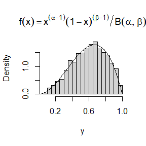

```r
rdistBETA = function(n = 1e3,alpha = 3,beta = 2,picture = FALSE){
  sample_total <- m <- 0 # draw the mth sample and Output sampling total
  y <- numeric(n) # Record the generated random numbers
  while(m < n)
  {
    u <- runif(1) # Generate random numbers from U(0,1)
    sample_total <- sample_total + 1
    x <- runif(1) # Generate random numbers from g(x)
    if(u <= x^(alpha-1)*(1-x)^(beta-1)) # Determine whether u <= rho(x)
    {
      # accept x and record it
      m <- m + 1
      y[m] <- x
    }
  }
  if(picture){
    # Draw a histogram
    hist(y, prob = TRUE, breaks = 'scott',main = expression(f(x)==x^(alpha-1)*(1-x)^(beta-1)/B(alpha,beta)))
    # Sampling and plotting probability density curves
    sampling <- seq(0,1,.01)
    lines(sampling,sampling^(alpha-1)*(1-sampling)^(beta-1)/beta(alpha,beta))
  }
  return(y)
}
y <- rdistBETA(1e3,3,2,TRUE)
```

```r
rm(list=ls())
```

We can find that the coincidence degree between the histogram drawn by the generated samples and the probability density curve is very high, that is, it can be considered that the generated random samples are from $Beta(\alpha=3,\beta=2)$.

### Question 3.12 & 3.13

The purpose of the question is to simulate a continuous Exponential-Gamma mixture with the rate parameter $\Lambda\sim$Gamma($r, \beta$) and $Y\sim$Exp($\Lambda$). Therefore, we have $(Y|\Lambda=\lambda)\sim f_Y (y|\lambda) = \lambda e^{−\lambda y}$. Besides, generate $n=1000$ random observations from this mixture with $r = 4$ and $\beta = 2$.

### Answer 3.12 & 3.13

Firstly, we can generate Gamma distributed random number $\lambda\sim Gamma(r,\beta)$ for $n=1000$ times, and then use each $\lambda$ to get the random sample $y_i\sim$Exp($\lambda_i$) with $i=1,...,n$.

In Exercise 3.12 we have generated random sample $y$ from this mixture distribution.

Therefore, we can then calculate the probability density function of this distribution according to its distribution function.

$$f(y)=F'(y)=-r(\frac{\beta}{\beta+y})^{r-1}(-\frac{\beta}{(\beta+y)^2})=\frac{r\beta^r}{(\beta+y)^{r+1}},y\geq
0.$$
Thus, we can plot histograms against samples and subsequently sample and plot theoretical probability density curves with $r = 4$ and $\beta = 2$.

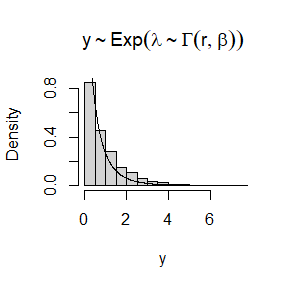

```r
rdistGammaExp = function(n = 1e3,r = 4,beta = 2,picture = FALSE){
  lambda_sampling <- rgamma(n,r,beta) # Generate gamma distributed random numbers
  y <- rexp(lambda_sampling) # the length of x and lambda is n = 1000
  if(picture){
    # Draw a histogram to show the random sample
    hist(y, prob = TRUE, breaks = 'scott',main = expression(y %~% Exp(lambda %~% Gamma(r,beta))))
    # Sampling and plotting probability density curves
    sampling <- seq(0,10,.01)
    lines(sampling,r*beta^r/(beta+sampling)^(r+1))
  }
  return(y)
}
x <- rdistGammaExp(1e3,4,2,TRUE)
```

```r
rm(list=ls())
```

We can find that the coincidence degree between the density histogram of the sample and the theoretical (Pareto) probability density curve is very high. Therefore, it can be considered that the shape of empirical and theoretical (Pareto) distributions is similar.

## HW2

The main task of HW2 is to test the performance of Monte Carlo method.

### Exercise 1

1. For $n = 10^4, 2 \times 10^4, 4 \times 10^4, 6 \times 10^4, 8 \times 10^4$, apply the fast sorting algorithm to randomly permuted numbers of $1, . . . , n$.
2. Calculate computation time averaged over 100 simulations, denoted by $a_n$.
3. Regress $a_n$ on $t_n := n log(n)$, and graphically show the results (scatter plot and regression line).

```r
quick_sort<-function(x){
  num<-length(x)
  if(num==0||num==1){return(x)
  }else{
    a<-x[1]
    y<-x[-1]
    lower<-y[y<a]
    upper<-y[y>=a]
    return(c(quick_sort(lower),a,quick_sort(upper)))}
}
```

```r
HW2_Ex1 <- function(n=100){
  set.seed(1)
  sample_n <- c(1,2,4,6,8) *1e4 # The array size
  test_time_sample <- numeric(length(sample_n)) # record spending time
  # calculate time
  for(i in 1:length(sample_n)){
    test_number<-sample(1:sample_n[i])
    test_time_sample[i] <- system.time(for(j in 1:n) quick_sort(test_number))[1]/n
  }
  cat('The average time:',test_time_sample)
  t <- sample_n*log(sample_n)
  t_test_time_lm <- lm(t~test_time_sample) # linear regression
  summary(t_test_time_lm)
  # graph the scatter plot and regression line
  plot(test_time_sample,t,main="Scatter plots and regression line")
  abline(t_test_time_lm,col='red')
  legend("topleft",legend="Regression line",col="red",lty=1)
}
```

```r
HW2_Ex1(100)
```

```
## The average time: 0.0681 0.0947 0.1903 0.2856 0.3833
```

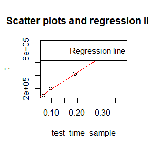

```r
rm(list = ls())
```

We can find that the scatter is distributed near the regression line and the linear regression result of $a_n$ is significant, so it can be considered that the computation amount of the quicksort algorithm is almost $O(n log(n))$ level.

### Question 5.6

Consider the antithetic variate approach to calculate
$$\theta=\int_0^1e^xdx$$
Compute $Cov(e^U , e^{1−U} )$ and $V ar(e^U + e^{1−U} )$, where $U\sim Uniform(0,1)$. Estimate the percent reduction in variance of $\hat{\theta}$ that can be achieved using antithetic variates (compared with simple MC).

Since $U\sim Uniform(0,1)$, we can easily get that $1-U\sim Uniform(0,1)$ and,

$$Cov(e^U , e^{1−U}
)=E(e^Ue^{1−U})-E(e^{U})E(e^{1−U})=e-E(e^{U})E(e^{1−U})$$

where $E(e^{1−U})=E(e^{U})=\int_0^1 e^udu=e-1$.

Therefore, $Cov(e^U , e^{1−U} )=e-(e-1)^2=-e^2+3e-1\approx -0.2342106$. And,

$$V ar(e^U + e^{1−U} ) = Var(e^U)+V
ar(e^{1−U} )+2Cov(e^U , e^{1−U} )$$
where $V ar(e^U)=V ar(e^{1-U})=E(e^{2U})-E(e^{U})^2=\int_0^1 e^{2u}du-(e-1)^2=\frac{e^2-1}{2}-(e-1)^2=(e-1)(\frac{e+1}{2}-(e-1))=\frac{(e-1)(3-e)}{2}$.

Thus, $V ar(e^U + e^{1−U} ) = (e-1)(3-e) + 2(-e^2+3e-1)=-3e^2+10e-5\approx 0.01564999$.

If we take $2n$ samples, considering the antithetic variate approach, we have

$$\hat{\theta}=\frac{1}{n}\sum_{i=1}^n\frac{e^{U_i}+e^{1-U_i}}{2}$$
also we have simple MC estimator as

$$\hat{\theta}_{MC}=\frac{1}{2n}\sum_{i=1}^{2n}e^{U_i}$$

with $U_i\sim U(0,1)$ i.i.d. for $i=1,...,2n$.

Also we can get the theoretical variance of $\hat{\theta}$ and $\hat{\theta}_{MC}$.

$$Var(\hat{\theta})=\frac{1}{n^2}\sum_{i=1}^nVar(\frac{e^{U_i}+e^{1-U_i}}{2})=\frac{1}{4n}Var(e^{U}+e^{1-U})=\frac{-3e^2+10e-5}{4n}$$
$$Var(\hat{\theta}_{MC})=\frac{1}{4n^2}\sum_{i=1}^{2n}Var(e^{U_i})=\frac{1}{2n}Var(e^{U})=\frac{(e-1)(3-e)}{4n}$$

$$(Var(\hat{\theta}_{MC})-Var(\hat{\theta}))/Var(\hat{\theta}_{MC})=1-Var(\hat{\theta})/Var(\hat{\theta}_{MC})=1-\frac{-3e^2+10e-5}{(e-1)(3-e)}\approx
0.9676701$$
Therefore, the percent reduction in variance of $\hat{\theta}$ that can be achieved using antithetic variates is 0.9676701 which can be said as 96.76701%.

### Question 5.7

Refer to Exercise 5.6. Use a Monte Carlo simulation to estimate $\theta$ by the antithetic variate approach and by the simple Monte Carlo method. Compute an empirical estimate of the percent reduction in variance using the antithetic variate. Compare the result with the theoretical value from Exercise 5.6.

```r
HW2_Q_5_7 <- function(n=1e3){
  set.seed(1)
  u <- runif(2*n) # Take the first n random numbers for Uniform distribution
  u1 <- u[1:n] # Take the first n random numbers
  theta_MC <- mean(exp(u)) # simple MC estimator
  theta <- mean((exp(u1)+exp(1-u1))/2) # antithetic variate approach
  cat('Simple MC estimator:',theta_MC,'\n')
  cat('Antithetic Variate estimator:',theta,'\n')
  var_theta <- var((exp(u1)+exp(1-u1))) / (4*n) # variance of antithetic variate approach
  var_theta_MC <- var(exp(u)) / (2*n) # variance of simple MC estimator
  cat('The percent reduction in variance:',1 - var_theta / var_theta_MC)
}
```

We have the simple MC estimator $\hat{\theta}_{MC}=1.711716$ and the estimator $\hat{\theta}=1.718079$ by antithetic variate approach which are both similar to the theoretical results $\theta = \int_0^1e^xdx=e-1\approx 1.718282$.

Besides, as mentioned above, we can get the theoretical variance of $\hat{\theta}$ and $\hat{\theta}_{MC}$.

$$Var(\hat{\theta})=\frac{-3e^2+10e-5}{4n}$$
and
$$Var(\hat{\theta}_{MC})=\frac{(e-1)(3-e)}{4n}$$
and have
$$(Var(\hat{\theta}_{MC})-Var(\hat{\theta}))/Var(\hat{\theta}_{MC})=1-Var(\hat{\theta})/Var(\hat{\theta}_{MC})=1-\frac{-3e^2+10e-5}{(e-1)(3-e)}\approx
0.9676701$$

```r
HW2_Q_5_7(1e3)
```

```
## Simple MC estimator: 1.711716
## Antithetic Variate estimator: 1.718079
## The percent reduction in variance: 0.9680734
```

```r
rm(list = ls())
```

Therefore, the empirical estimate of the percent reduction in variance of $\hat{\theta}$ that can be achieved using antithetic variates is 0.9680734 nearly 96.8%, which is similar to the theoretical value $1-\frac{-3e^2+10e-5}{(e-1)(3-e)}\approx 0.9676701$.

## HW3

HW3 is mainly a test of importance sampling and hierarchical importance sampling.

### Question 5.13

Find two importance functions $f_1$ and $f_2$ that are supported on $(1, \infty)$ and are ‘close’ to
$$g(x)=\frac{x^2}{\sqrt{2\pi}}e^{-x^2/2},x>1,$$
Determine and explain which of the importance functions should produce the smaller variance in estimating

$$\int_1^{+\infty}\frac{x^2}{\sqrt{2\pi}}e^{-x^2/2}dx.$$

### Answer 5.13

To find an importance function similar to $g(x)$ with supported on $(1,\infty)$, we can first plot the function of $g(x)$.

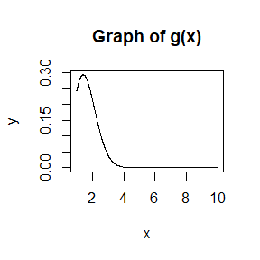

```r
x <- seq(1,10,0.01) #sampling
y <- x^2 * exp(- x^2/2) / sqrt(2*pi) # function of g(x)
plot(x,y,col = 'black',xlim = c(1,10),type = 'l',ylab = 'y',main = 'Graph of g(x)')
```

Then we choose to find a function that has tail approximately zero, and a larger value near 1.

Therefore, we consider
$$f_1(x)=c_1e^{-x},x>1,$$
$$f_2(x)=c_2e^{-x/2},x>1.$$
And choose $c_1$ and $c_2$ to make the integration of $f_1(x)$ and $f_2(x)$ equal to 1.

$$1/c_1=\int_1^{+\infty}
e^{-x}dx=e^{-1}$$
$$1/c_2=\int_1^{+\infty}
e^{-x/2}dx=2e^{-1/2}$$

Therefore, we have
$$f_1(x)=e^{-(x-1)},x>1,$$
$$f_2(x)=\frac{1}{2}e^{-(x-1)/2},x>1.$$

Then we have the cdf as followed,

$$F_1(t) = \int_1^t e^{-(x-1)} dx =
1-e^{-(t-1)},t>1,$$
$$F_2(t) =
\int_1^t \frac{1}{2}e^{-(x-1)/2} dx = 1-e^{-(t-1)/2},t>1,$$
and make $F_1(t) = U_1$ and $F_2(t) = U_2$ with $U_1,U_2\sim U(0,1)$ and obtain the formula for random number generation.

$$X_1 = - log(1-U_1) +1,X_1\sim
F_1,$$
$$X_2 = - 2log(1-U_2)
+1,X_2\sim F_2.$$
We generate $n=1e4$ random numbers.

```r
set.seed(1)
n <- 1e4 # random numbers size
x1 <- -log(1-runif(n)) + 1 # X1~F1
x2 <- -2 * log(1-runif(n)) + 1 # X2~F2
```

Then, from the theory of importance sampling, we can get

$$\int g(x)dx=\int
\frac{g(x)}{f(x)}f(x)dx=E_f(\frac{g(x)}{f(x)})$$

So we can get two important sampling estimators of
$$\int_1^{+\infty}\frac{x^2}{\sqrt{2\pi}}e^{-x^2/2}dx$$
as follows.

$$\hat{\theta}_1 = \frac{1}{n}\sum_{i=1}^n
\frac{g(X_{1i})}{f_1(X_{1i})},X_{1i}\sim F_1, i=1,...,n,$$
$$\hat{\theta}_2 = \frac{1}{n}\sum_{i=1}^n
\frac{g(X_{2i})}{f_2(X_{2i})},X_{2i}\sim F_2, i=1,...,n,$$
And
$$Var(\hat{\theta}_1) =
\frac{1}{n^2}Var(\sum_{i=1}^n
\frac{g(X_{1i})}{f_1(X_{1i})})=\frac{1}{n}Var(\frac{g(X_{1})}{f_1(X_{1})})$$
$$Var(\hat{\theta}_2) =
\frac{1}{n^2}Var(\sum_{i=1}^n
\frac{g(X_{2i})}{f_2(X_{2i})})=\frac{1}{n}Var(\frac{g(X_{2})}{f_2(X_{2})})$$

Also, we can use the sample variance to estimate the variance.

```r
theta_hat1 <- x1^2 * exp(- x1^2/2) / sqrt(2*pi) / exp(- (x1 - 1))
theta_hat2 <- x2^2 * exp(- x2^2/2) / sqrt(2*pi) / (exp(- (x2 - 1)/2) / 2)
var_theta1 <- var(theta_hat1) / n # variance of f1 important sampling
var_theta2 <- var(theta_hat2) / n # variance of f2 important sampling
print(c(mean(theta_hat1),mean(theta_hat2)))
```

```
## [1] 0.3968767 0.4000743
```

```r
print(c(var_theta1,var_theta2))
```

```
## [1] 2.509930e-06 9.093186e-06
```

We can find that $Var(\hat{\theta}_1) < Var(\hat{\theta}_2)$. In other words, sampling the importance of $f_1(x)$ gives you a smaller variance.

We can infer the reason for this result by graphing the function of $g(x),f_1(x)$ and $f_2(x)$ in the same plot.

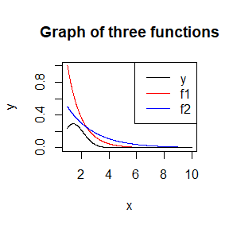

```r
x <- seq(1,10,0.01)
y <- x^2 * exp(- x^2/2) / sqrt(2*pi) # g(x)
f1_ing <- exp(- (x - 1)) # f1(x)
f2_ing <- exp(- (x - 1)/2) / 2 # f2(x)
plot(x,f1_ing,col = 'red',xlim = c(1,10),type = 'l',ylab = 'y',main = 'Graph of three functions')
lines(x,f2_ing,col = 'blue')
lines(x,y,col = 'black')
legend('topright',c('y','f1','f2'),col = c('black','red','blue'),lty=1)
```

And graph the ratio of $g(x)/f_1(x)$ and $g(x)/f_2(x)$.

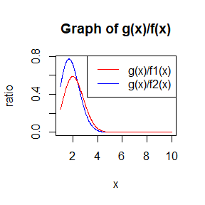

```r
plot(x,y / f2_ing,col = 'blue',xlim = c(1,10),type = 'l',ylab = 'ratio',main = 'Graph of g(x)/f(x)')
lines(x,y / f1_ing, col = 'red')
legend('topright',c('g(x)/f1(x)','g(x)/f2(x)'),col = c('red','blue'),lty=1)
```

It can be found that compared with $g(x)/f_2(x)$, the curve of $g(x)/f_1(x)$ changes more gently, so the ratio of $g(x)/f_1(x)$ is closer to the constant than $g(x)/f_2(x)$, so the estimated variance is smaller.

### Question 5.15

Obtain the stratified importance sampling estimate in Example 5.13 and compare it with the result of Example 5.10.

### Answer 5.15

According to the meaning of the question, we choose importance function $f_3(x)=\frac{e^{-x}}{1-e^{-1}},0<x<1$ to conduct importance stratified sampling of function $g(x)=\frac{e^{-x}}{1+x^2}$ in five segments in the interval $(0,1)$.

Therefore, we can get
$$\int_0^1
g(x)dx=\sum_{j=1}^5\int_{\frac{j-1}{5}}^{\frac{j}{5}}g_j(x)dx=\sum_{j=1}^5\int_{\frac{j-1}{5}}^{\frac{j}{5}}\frac{g_j(x)}{f_j(x)}f_j(x)dx$$

with $g_j(x)=g(x)$,$x\in(\frac{j-1}{5},\frac{j}{5}),j=1,2,3,4,5$ and $g_j(x)=0$ otherwise. And we should make $f_j(x)=5c_jf(x),\frac{j-1}{5}<x<\frac{j}{5},j=1,2,3,4,5$.

Let $\int_{\frac{j-1}{5}}^{\frac{j}{5}} f_j(x)dx=1$, we have

$$1/c_j=\int_{\frac{j-1}{5}}^{\frac{j}{5}}
5f(x)dx=\int_{\frac{j-1}{5}}^{\frac{j}{5}}
\frac{5e^{-x}}{1-e^{-1}}dx=\frac{5(e^{-{(j-1)/5}}-e^{-{j/5}})}{1-e^{-1}},j=1,2,3,4,5,$$
$$f_j(x)=5c_jf(x)=\frac{e^{-x}}{e^{-{(j-1)/5}}-e^{-{j/5}}},\frac{j-1}{5}<x<\frac{j}{5}\
for\ j=1,2,3,4,5.$$
$$F_j(t) =
\int_{\frac{j-1}{5}}^t
\frac{e^{-x}}{e^{-{(j-1)/5}}-e^{-{j/5}}}dx=\frac{e^{-{(j-1)/5}}-e^{-{t}}}{e^{-{(j-1)/5}}-e^{-{j/5}}},\frac{j-1}{5}<t<\frac{j}{5}.$$
Therefore, we can generate $X_{ij}\sim F_j$ by making $F_j(t) = U$ and getting
$$X_j=-log(e^{-{(j-1)/5}} -
(e^{-{(j-1)/5}}-e^{-{j/5}})U_j),U_j\sim U(0,1)$$

Then
$$\hat{\theta}_j=\frac{1}{m}\sum_{i=1}^m
\frac{g_j(X_{ij})}{f_j(X_{ij})}=\frac{1}{m}\sum_{i=1}^m
\frac{e^{-{(j-1)/5}}-e^{-{j/5}}}{1+X_{ij}^2},X_{ij}\sim F_j$$
and
$$\hat{\theta}^{SI}=\sum_{j=1}^5
\hat{\theta}_j$$
with
$$Var(\hat{\theta}^{SI})=\sum_{j=1}^5
Var(\hat{\theta}_j)=\sum_{j=1}^5 \frac{\sigma_j^2}{m},$$
$$\sigma_j^2=Var(\frac{g_j(X_j)}{f_j(X_j)}),X_j\sim
F_j.$$

```r
set.seed(1)
k <- 5 # numbers of layers
n <- 10000# total sampling
m <- n / k # sampling number in each layer
theta_hat <- theta_var <- 0
for(j in 1:k)
{
  x <- -log(exp(-(j-1)/5)-(exp(-(j-1)/5)-exp(-j/5))*runif(m)) # generate xj~Fj
  theta <- (exp(-(j-1)/5)-exp(-j/5)) / (1 + x^2) # calculate g(Xj)/fj(Xj)
  theta_hat <- theta_hat + mean(theta) # estimate theta
  theta_var <- theta_var + var(theta)/m # estimate varience of theta
}
theta_hat
```

```
## [1] 0.5246902
```

```r
theta_var
```

```
## [1] 3.154865e-08
```

```r
rm(list=ls())
```

We can get the result $\hat{\theta}^{SI}=0.5246902$ and $Var(\hat{\theta}^{SI})=3.154865e-08$. It can be found that $\hat{\theta}^{SI}$ is similar to $\hat\theta= 0.5257801$ and $Var(\hat{\theta}^{SI})$ is smaller than $Var(\hat\theta)/n = 0.0970314/n=9.70314e-06$.

## HW4

HW4 is mainly used for hypothesis testing and confidence interval calculation.

### Question 6.4

Suppose that $X_1,...,X_n$ are a random sample from a from a lognormal distribution with unknown parameters. Construct a 95% confidence interval for the parameter $\mu$. Use a Monte Carlo method to obtain an empirical estimate of the confidence level.

### Answer 6.4

Since $X_1,...,X_n$ are a random sample from a from a lognormal distribution, so we can assume that

$$lnX_i\sim N(\mu,\sigma^2),i.i.d\ for\
i=1,...,n.$$
and $\mu$ and $\sigma^2$ are both unknown.

Therefore, we have
$$T =
\frac{\bar{lnX}-\mu}{s/\sqrt{n}}\sim t_{n-1}$$
with $\bar{lnX}=\frac{1}{n}\sum_{i=1}^nlnX_i$ and $s^2=\frac{1}{n-1}\sum_{i=1}^n(lnX_i-\bar{lnX})^2$, $t_{n-1}$ is t distribution with freedom $n-1$.

So we have $1-\alpha$ confidence interval for $\mu$ is

$$(\bar{lnX}-\frac{s}{\sqrt{n}}t_{1-\alpha/2}(n-1),\bar{lnX}+\frac{s}{\sqrt{n}}t_{1-\alpha/2}(n-1))$$

Make $\alpha=0.05$, we have 95% confidence interval for $\mu$ is

$$(\bar{lnX}-\frac{s}{\sqrt{n}}t_{0.975}(n-1),\bar{lnX}+\frac{s}{\sqrt{n}}t_{0.975}(n-1))$$

If we want to use MC method to obtain an empirical estimate of the confidence level, we can repeat to general $X_i,i=1,...,n$ to $m$ times with distribution $lnX_i\sim N(\mu_0,\sigma_0^2)$.

```r
# generate and save data
set.seed(1)
sampling <- function(n = 1e2, m = 1e3, mu = 0, sigma = 1){
  y <- rnorm(n*m,mean = mu, sd = sigma) # generate normal random sample
  x <- exp(y) # generate log normal sample from normal random sample
  return(x) # Clean up the memory
}
```

For each time $k$, calculate confidence intervel $(\hat\mu_{1k},\hat\mu_{2k})=(\bar{lnX}-\frac{s}{\sqrt{n}}t_{1-\alpha/2}(n-1),\bar{lnX}+\frac{s}{\sqrt{n}}t_{1-\alpha/2}(n-1))$ and determine whether $\mu_0$ is in the above range, getting $I(\mu_0\in (\hat\mu_{1k},\hat\mu_{2k}))$.

```r
# analyzing data
analyzing <- function(n = 1e2, m = 1e3,alpha=0.05,mu = mu){
  x_all <- sampling(n,m,mu,sigma=1)
  result <- numeric(m)
  # calculate confidence interval
  for(i in 1:m){
    x <- x_all[((i-1)*n+1):(i*n)]
    lower <- mean(log(x))-qt(1-alpha/2,length(x)-1)*sqrt(var(log(x)))/sqrt(length(x))
    upper <- mean(log(x))+qt(1-alpha/2,length(x)-1)*sqrt(var(log(x)))/sqrt(length(x))
    result[i] <- (lower < mu) * (upper > mu) # judge whether mu in confidence interval
  }
  result
}
```

Finally, get $\hat{CP}=\frac{1}{m}\sum_{k=1}^m I(\mu_0\in (\hat\mu_{1k},\hat\mu_{2k}))$ as empirical estimate of the confidence level.

```r
# result and summary
showing <- function(n = 1e2, m = 1e3, mu = 0, alpha = 0.05){
  sampling(n=n,m=m,mu = mu)
  result <- analyzing(n=n,m=m,alpha = alpha, mu = mu)
  print(mean(result))
}
```

We can write it as follow R code with $n=100$ and $m=1000$ and test $\mu_0=0,10$ and $100$.

```r
# test
set.seed(1)
showing(n = 1e2, m = 1e3, mu = 0, alpha = 0.05)
```

```
## [1] 0.948
```

```r
showing(n = 1e2, m = 1e3, mu = 10, alpha = 0.05)
```

```
## [1] 0.948
```

```r
showing(n = 1e2, m = 1e3, mu = 100, alpha = 0.05)
```

```
## [1] 0.945
```

```r
rm(list=ls())
```

All of empirical estimators of the confidence level is similar to 0.95.